# Pesticide Study Rainfall Generator Instructions

Brian Hafar

3/10/2021

# 1 Introduction

I will try to make this explanation as consice as possible while still hitting all the major points which should be included in you report. Since I’m not sure what your state of knowledge is regarding statical distributions, I will try to make things as simple to understand as possible by relating the concepts detailed here with their practical application for the study project.

Generating a random sample from both the Poisson and exponential distributions requires us to define a single variable, which we call the rate parameter. The rate parameter is typically denoted as $\lambda$ and describes how often something is happening. A typical application is determining the arrival time of storm events. In our case, we treat $\lambda$ slightly different and assume that it can not only describe how often wet pulses happen (which gives us the dry duration), but also that it can describe how long a wet pulse duration is. To bring this into perspective, when we define `dry` for the dry duration and `duration` for the wet duration, we are really just defining $\lambda$ as the **average** rate for whichever distribution we choose. However, there is a caveat for the exponential distribution that I will clear up in the functions section. I don’t think you were randomizing the rainfall depth as well, but we can apply the same logic here and define $\lambda$ as the average rainfall intensity among all wet intervals in the time series.

The two distributions have very different typical probability functions. This is true not only in the shape of the probability curve, but also in the values for which the functions are valid, also called the **support**. I’ll discuss the relevant implications of these points in the chapters below. For now, just take a look at the plots below and compare the probability density shapes.

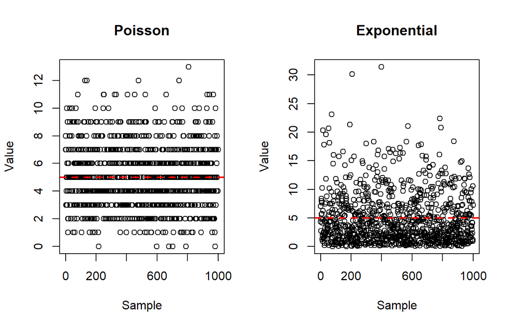

Each plot is a representation of 1000 randomly sampled numbers from each distribution, with each sampled set having an average value of 5 (marked by the red line). There are a few things to point out that will help us understand what role the distributions play. First is that the sampled numbers from the Poisson distribution are only positive integer values (hence the banding), while the exponential distribution has continuous values. Second is that the spread of the values on the y-axis for the Poisson sample are more or less all grouped together, while the exponential sample has a higher grouping of lower values with a much larger range than with Poisson. If wee think about this in the context of sampling pulse durations, the Poisson distribution will tend to produce somewhat similar durations, and the exponential distribution will tend to produce many small durations and also a few quite large durations.

The value that the each random sample takes is based on the probability mass function (PMF) for the Poisson distribution and the probability density function (PDF) for the exponential distribution. I’ll go into the distinction below. For now we’ll just see how each function looks.

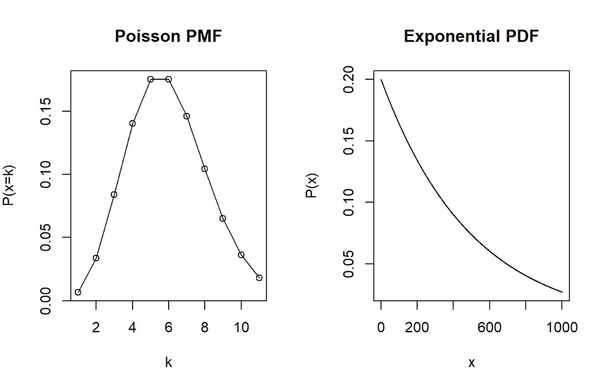

The Poisson distribution is an approximation of the binomial distribution. It is characterized by a discrete bell-shaped PMF curve where majority of the probability is grouped around a central point. On the other hand the exponential distribution has the highest probability among the lowest values. The probability exponentially decreases toward the higher values. Much of what I’m discussing here is well-described in the Wikipedia pages, which can be found [here](https://en.wikipedia.org/wiki/Poisson_distribution) for the Poisson distribution and [here](https://en.wikipedia.org/wiki/Exponential_distribution) for the exponential distribution. There is quite a bit more information on these pages than you will need to understand the basic principles provided here, but they are a nice extended resource.

# 2 Poisson distribution equations

In reality, due to the typical bell-shaped curve, the Poisson distribution does not really fit well to real world precipitation data since the largest share of the probability density is more or less tightly grouped around whichever value we define as $\lambda$. This results in only a slight randomization of pulse durations when compared to the constant pulse durations, since the more extreme values have a very low probability density. If the Hydrus outputs were to show large fluctuations in the mass balance curve given a Poisson distribution for wet/dry pulses, we would might be able to say that the dissipation rate is highly sensitive to changes in the wet/dry pulse durations. This does not seem to be the case here, since the the results are quite similar to constant pulse durations.

The support for the Poisson distribution is $k \in \mathbb{N}_0$, meaning that any natural number (positive integer) starting from zero can be considered, where $k$ is the number of occurrences. For us, this would mean the number of random pulses we need to fill out the time series until `maxTime` is reached (this is considering wet and dry pulses separately). With this we can formally define the PMF for the Poisson distribution as:

The last thing I want to discuss is how the output from the random Poisson number generator relates to the hourly timestep of the precipitation time series. In that, no further calculations need to be made regarding the durations generated by this method as they will always be integer values (this is not the case for the exponential distribution). The only modification that happens with this distribution results from the condition that our time series will consist of alternating wet and dry pulses, which means that any generated pulses with zero duration are discarded and a new random number is sampled in order to maintain the desired structure.

# 3 Exponential distribution equations

On the other hand, we have have the exponential distribution. Observational data does often fit well to the exponential distribution, both in terms of wet and dry pulse durations. Although, the goodness of fit is very dependent on how the wet/dry pulses are defined, so I’m not going to get into that here. This is not super relevant for the study project, at least not yet. In your case we are using a very simplified approach, such as not really allowing wet pulse intensity variability, to identify what response individual changes make to the model output.

Contrary to the Poisson distribution, the exponential distribution has a very steep probability density curve. This results in many short duration pulses being generated, and also few but substancially longer pulses as well. The support for the exponential distribution is $x \in [0,\infty)$, meaning that any number from 0 to infinity is considered. We explicitly define the probability of zero as zero, since the exponential function has zero as an asymptote. With this we can formally define the PDF for the exponential distribution as:

$$f(x;\lambda) = \begin{cases} \lambda e^{-\lambda x} & x \ge 0 \\ 0 & x \lt0 \end{cases}$$

The expected value of $X$ for the exponential distribution is:

$$\text{E}(X)=\frac{1}{\lambda}$$

and the variance of $X$ is:

$$\text{Var}(X)= \frac{1}{\lambda^2}$$
which means that the standard deviation is equal to the expected value.

With the Poisson distribution $\lambda$ and the expected value are equal, which let is directly define `dry` or `duration` as the average value for the generated pulse durations. To have this same effect with the exponential distribution, we need to take the inverse of `dry` or `duration` and pass that value to $\lambda$.

We can consider the inverse value explicitly for the exponential PDF by defining the scale parameter ($\beta$) such that $\beta = 1/\lambda$, which is also the mean. With this we can rewrite the PDF as:

where we can directly pass either `dry` or `duration` to $\beta$.

Since the PDF of the exponential distribution is continuous, any randomly generated number is rounded to the nearest integer value to maintain the wet/dry pulse cycle. If zero duration values are created, they are ignored and sampled again in the same way explained in the Poisson section.

# 4 Note on sorting the pulses

For all the different sorting algorithms (e.g. random, (q)peak, (q)valley), the distribution histogram of the pulse durations, as well as the wet intensities, will remain the same. The only difference is the position within the time series sequence.

# 5 References

Ahrens, J. H. and Dieter, U. (1972). Computer methods for sampling from the exponential and normal distributions. Communications of the ACM, 15, 873–882.

Ahrens, J. H. and Dieter, U. (1982). Computer generation of Poisson deviates from modified normal distributions. ACM Transactions on Mathematical Software, 8, 163–179.